# Tugas Praktikum ARIMA MPDW

Sintya Sulis

2026-10-01

```r
library(ggplot2)
library(tsibble)
library(tseries)
library(MASS)
library(forecast)
library(TSA)
library(TTR)
library(aTSA)
library(graphics)
```

## Data Real

Digunakan data *Consumer Price Index: All Items: Total for Indonesia* (kode seri CPALTT01IDM657N) dari FRED (sumber: OECD), yaitu laju pertumbuhan CPI bulanan (persen terhadap bulan sebelumnya). Data asli berisi 505 bulan, yaitu Maret 1982 sampai Maret 2024. Seluruh 505 periode digunakan dalam analisis

```r
datacpi<-rio::import("/Users/sintyasulis/Documents/MPDW/CPALTT01IDM657N.xlsx")
datacpi <- datacpi[1:505,2]
datacpi.ts<-ts(datacpi)
```

### Eksplorasi Data

#### Plot Data Penuh

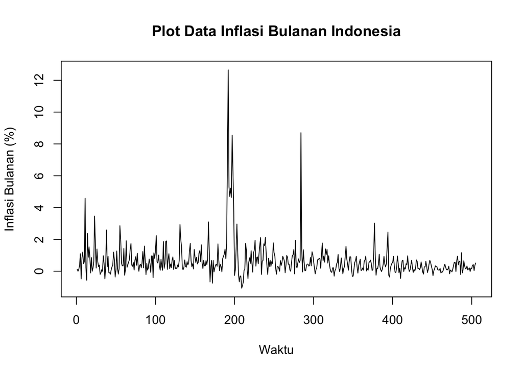

```r
plot.ts(datacpi.ts,
        lty = 1,
        xlab = "Waktu",
        ylab = "Inflasi Bulanan (%)",
        main = "Plot Data Inflasi Bulanan Indonesia")
```

Berdasarkan plot data deret waktu, terlihat bahwa data cenderung bergerak di sekitar nilai tengah tertentu. Namun, terdapat beberapa lonjakan yang cukup besar pada periode tertentu. Berdasarkan pola data, pembagian data latih dan data uji ditetapkan dengan proporsi 80%:20%, yaitu 404 periode data latih dan 101 periode data uji

#### Plot Data Latih

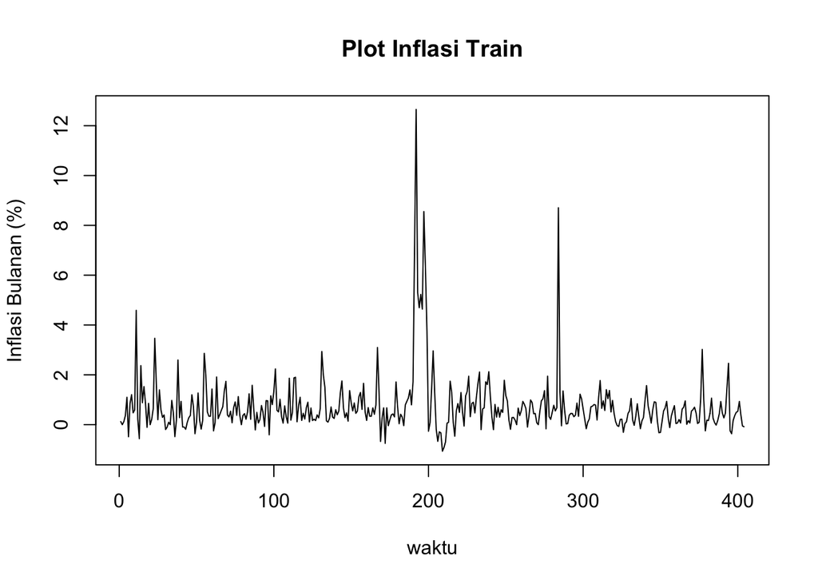

```r
cpitrain<-datacpi[1:404]
train.ts<-ts(cpitrain)
plot.ts(train.ts, lty=1, xlab="waktu", ylab="Inflasi Bulanan (%)", main="Plot Inflasi Train")
```

Berdasarkan plot data deret waktu pada data latih, terlihat bahwa data cenderung bergerak di sekitar nilai tengah tertentu dan tidak menunjukkan pola tren yang jelas. Hal ini mengindikasikan bahwa data cenderung stasioner dalam rataan. Namun, terlihat adanya beberapa lonjakan data dan lebar pita data yang belum seragam sehingga data diduga belum stasioner dalam ragam

#### Plot Data Uji

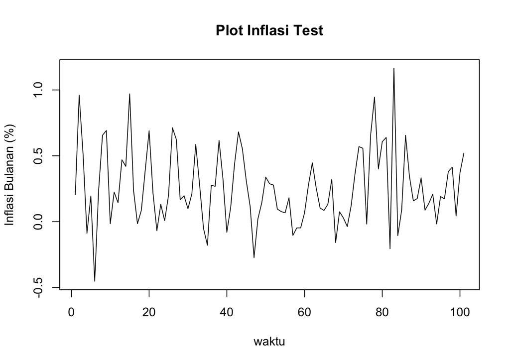

```r
cpitest<-datacpi[405:505]
test.ts<-ts(cpitest)
plot.ts(test.ts, lty=1, xlab="waktu", ylab="Inflasi Bulanan (%)", main="Plot Inflasi Test")
```

### Uji Stasioneritas Data

#### Plot ACF

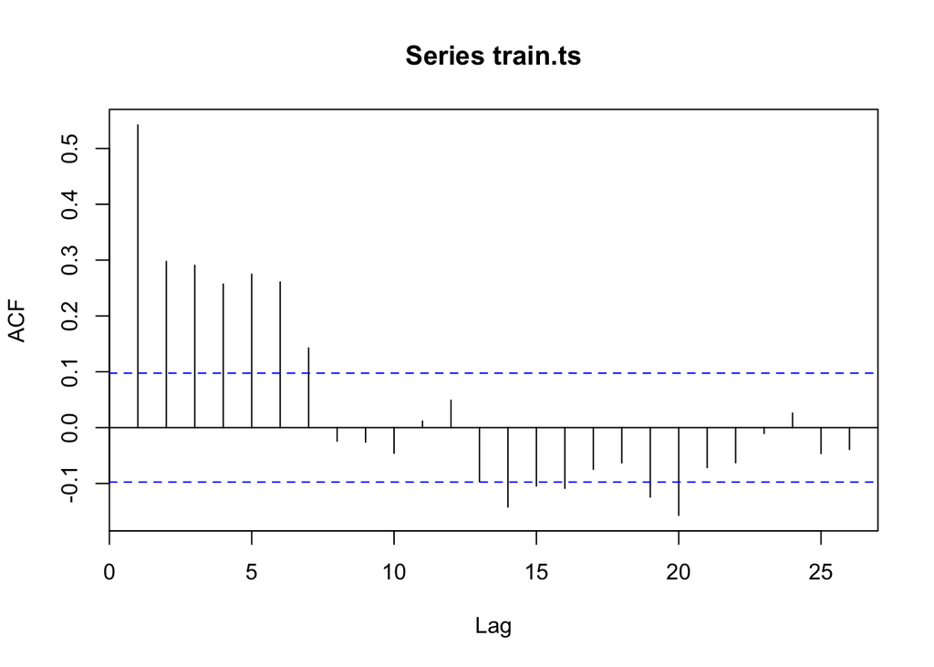

```r
acf(train.ts)
```

Berdasarkan plot ACF, terlihat bahwa nilai autokorelasi pada beberapa lag awal masih cukup besar dan menurun secara bertahap hingga sekitar lag 7. Pola tersebut menunjukkan adanya ketergantungan antarwaktu pada beberapa lag awal dan menjadi indikasi bahwa data perlu diperiksa lebih lanjut terkait kestasionerannya dalam rataan

#### Uji ADF

```r
tseries::adf.test(train.ts)
```

```
##
##  Augmented Dickey-Fuller Test
##
## data:  train.ts
## Dickey-Fuller = -6.01, Lag order = 7, p-value = 0.01
## alternative hypothesis: stationary
```

$H_0$ : Data tidak stasioner dalam rataan

$H_1$ : Data stasioner dalam rataan

Berdasarkan uji ADF tersebut, didapat *p-value* sebesar 0,01 yang lebih kecil dari taraf nyata 5% sehingga tolak $H_0$ dan menandakan bahwa data stasioner dalam rataan. Hal ini tidak sepenuhnya sesuai dengan hasil eksplorasi menggunakan plot time series dan plot ACF. Namun, berdasarkan uji formal ADF, data dapat dikatakan stasioner dalam rataan sehingga dapat dilanjutkan ke tahap selanjutnya

#### Plot Box-Cox

Data inflasi memuat nilai negatif dan nol sehingga tidak dapat langsung diuji menggunakan Box-Cox. Oleh karena itu, data digeser dengan menambahkan konstanta agar nilai minimumnya menjadi lebih besar dari nol.

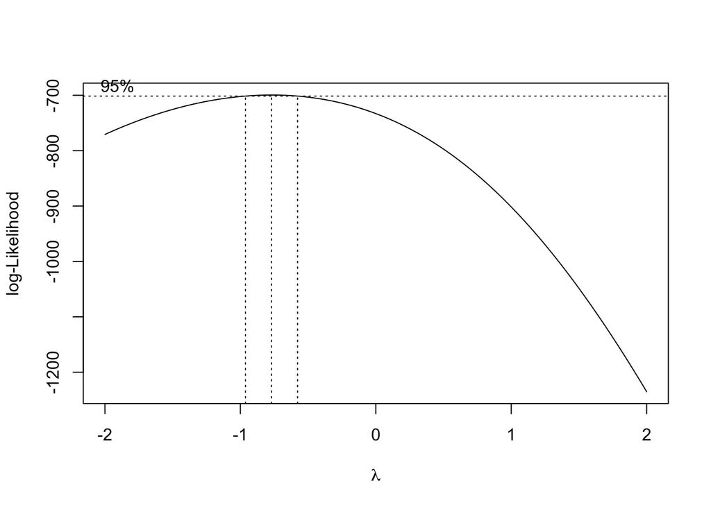

```r
index <- seq(1:404)

# Cek apakah ada nilai negatif/nol. Jika ada, tambahkan konstanta (c)
# agar nilai minimum data menjadi > 0 (misalnya menjadi 1)
min_val <- min(train.ts)

if (min_val <= 0) {
  c <- abs(min_val) + 1
  train.shifted <- train.ts + c
} else {
  train.shifted <- train.ts
}

# Box-Cox
bc <- boxcox(train.shifted ~ index, lambda = seq(-2, 2, by = 0.01))
```

```r
# Nilai lambda optimum (rounded)
lambda_opt <- bc$x[which.max(bc$y)]
lambda_opt
```

```
## [1] -0.77
```

```r
# Selang kepercayaan 95% untuk lambda
ci_lambda <- bc$x[bc$y > max(bc$y) - 0.5 * qchisq(0.95, df = 1)]

# Batas bawah dan batas atas
ci_lower <- min(ci_lambda)
ci_upper <- max(ci_lambda)

c(Batas_Bawah = ci_lower, Batas_Atas = ci_upper)
```

```
## Batas_Bawah  Batas_Atas
##       -0.96       -0.58
```

Gambar di atas menunjukkan nilai *rounded value* ($\lambda$) optimum sebesar -0,77 dan pada selang kepercayaan 95% nilai memiliki batas bawah -0,96 dan batas atas -0,58. Selang tersebut tidak memuat nilai satu sehingga dapat dikatakan bahwa data tidak stasioner dalam ragam. Oleh karena itu, dilakukan transformasi Box-Cox untuk menstabilkan ragam data

```r
train.trans <- (train.shifted^lambda_opt - 1) / lambda_opt
```

### Penanganan Ketidakstasioneran Data

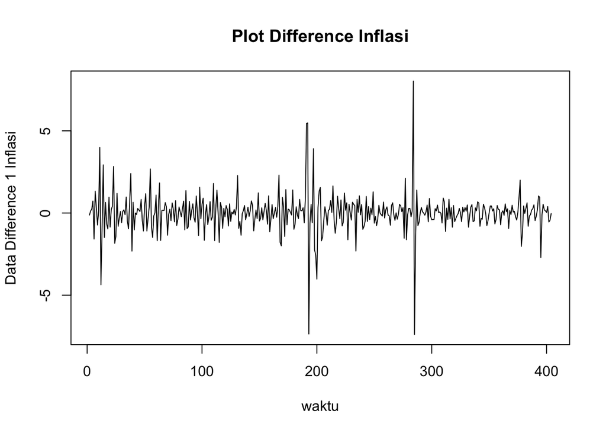

```r
# Dufferencing pertama
train.diff<-diff(train.ts,differences = 1)

# Plot hasil differencing
plot.ts(train.diff, lty=1, xlab="waktu", ylab="Data Difference 1 Inflasi", main="Plot Difference Inflasi")
```

Berdasarkan plot data deret waktu setelah differencing, terlihat bahwa data bergerak di sekitar nilai tengah nol dan tidak menunjukkan pola tren ataupun pola musiman yang jelas. Hal ini menunjukkan bahwa data sudah stasioner dalam rataan

#### Plot ACF

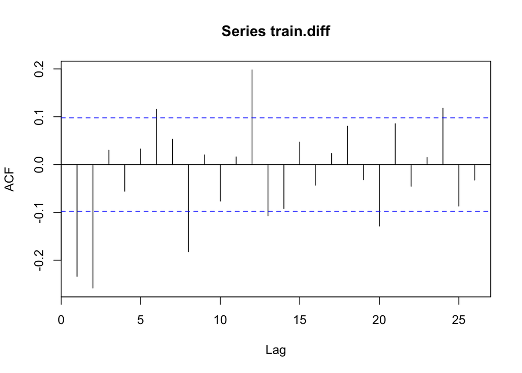

```r
acf(train.diff)
```

Berdasarkan plot ACF setelah differencing, terlihat bahwa masih terdapat beberapa spike yang melewati batas signifikansi pada beberapa lag. Pola ACF tidak menunjukkan cut off yang jelas pada satu lag tertentu. Meskipun demikian, data telah menunjukkan pola yang berfluktuasi di sekitar nilai nol sehingga hasil kestasioneran selanjutnya dikonfirmasi menggunakan uji ADF

#### Uji ADF

```r
tseries::adf.test(train.diff)
```

```
##
##  Augmented Dickey-Fuller Test
##
## data:  train.diff
## Dickey-Fuller = -8.5629, Lag order = 7, p-value = 0.01
## alternative hypothesis: stationary
```

$H_0$ : Data tidak stasioner dalam rataan

$H_1$ : Data stasioner dalam rataan

Berdasarkan uji ADF tersebut, didapat *p-value* sebesar 0,01 yang lebih kecil dari taraf nyata 5% sehingga tolak $H_0$ dan menandakan bahwa data stasioner dalam rataan. Hal ini menunjukkan bahwa data sudah stasioner dalam rataan dan ketidakstasioneran data telah berhasil tertangani

### Identifikasi Model

#### Plot ACF

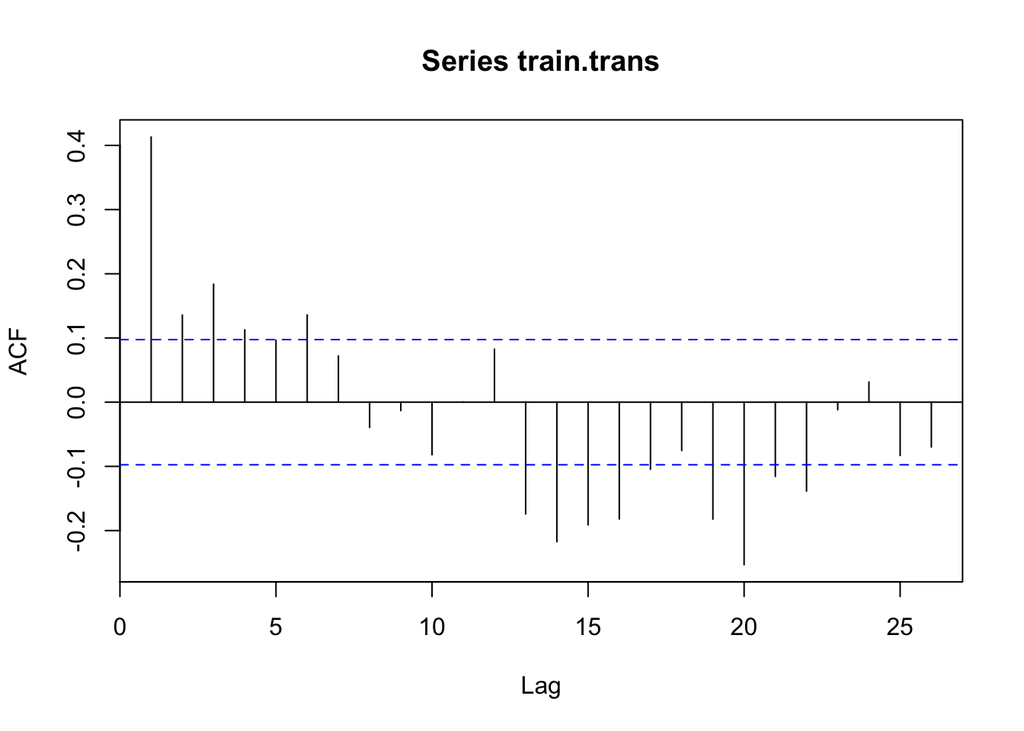

```r
acf(train.trans)
```

Berdasarkan plot ACF, terlihat bahwa nilai autokorelasi pada beberapa lag awal masih signifikan dan kemudian cenderung menurun serta berfluktuasi di sekitar nol. Dengan demikian, plot ACF cenderung menunjukkan pola tails off sehingga mengindikasikan adanya komponen AR pada model. Oleh karena itu, diperlukan plot PACF dan EACF untuk menentukan orde model tentatif

#### Plot PACF

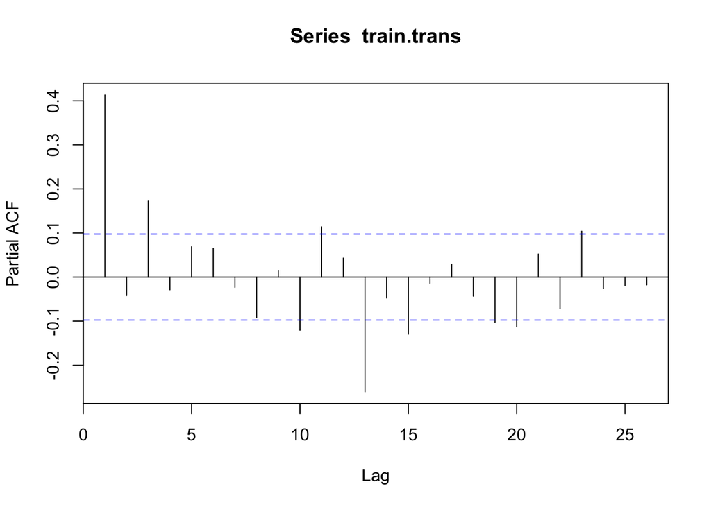

```r
pacf(train.trans)
```

Berdasarkan plot PACF, terlihat bahwa terdapat spike yang cukup signifikan pada beberapa lag awal, terutama pada lag 1 dan lag 3. Setelah lag tersebut, sebagian besar nilai PACF berada di sekitar batas signifikansi meskipun masih terdapat beberapa spike pada lag yang lebih tinggi. Pola pada beberapa lag awal mengindikasikan adanya komponen AR hingga orde 3, sehingga salah satu model tentatif yang dapat dipertimbangkan adalah ARIMA(3,0,0)

#### Plot EACF

```r
eacf(train.trans)
```

```
## AR/MA
##   0 1 2 3 4 5 6 7 8 9 10 11 12 13
## 0 x x x x o x o o o o o  o  x  x
## 1 o x x o o x o o o o o  o  x  o
## 2 x x o o o o o o o o o  o  x  x
## 3 x x o x o o o o o o o  o  x  x
## 4 x x x x x o x o o o o  o  x  x
## 5 x x o o x o o o o o o  o  x  o
## 6 x x x o x x x o o o o  o  x  x
## 7 x x x o x o x o o o o  o  x  o
```

Identifikasi model menggunakan plot EACF dilakukan dengan melihat pola segitiga yang terbentuk dari simbol o. Berdasarkan hasil EACF, terlihat adanya pola o yang membentuk area segitiga pada beberapa kombinasi orde AR dan MA. Oleh karena itu, EACF digunakan sebagai informasi tambahan dalam menentukan beberapa model tentatif yang selanjutnya dibandingkan berdasarkan signifikansi parameter dan nilai AIC

### Pendugaan Parameter Model Tentatif

#### ARIMA(3,0,0)

```r
model1.da=Arima(train.trans, order=c(3,0,0),method="ML")
summary(model1.da)
```

```
## Series: train.trans
## ARIMA(3,0,0) with non-zero mean
##
## Coefficients:
##          ar1      ar2     ar3    mean
##       0.4375  -0.1147  0.1723  0.6710
## s.e.  0.0490   0.0533  0.0490  0.0117
##
## sigma^2 = 0.01422:  log likelihood = 287.75
## AIC=-565.5   AICc=-565.35   BIC=-545.49
##
## Training set error measures:
##                        ME      RMSE        MAE MPE MAPE      MASE        ACF1
## Training set 0.0001737976 0.1186551 0.08937046 Inf  Inf 0.8300033 0.005737084
```

```r
lmtest::coeftest(model1.da)
```

```
##
## z test of coefficients:
##
##            Estimate Std. Error z value  Pr(>|z|)
## ar1        0.437505   0.048957  8.9365 < 2.2e-16 ***
## ar2       -0.114677   0.053289 -2.1520 0.0313985 *
## ar3        0.172253   0.048953  3.5188 0.0004335 ***
## intercept  0.671050   0.011652 57.5897 < 2.2e-16 ***
## ---
## Signif. codes:  0 '***' 0.001 '**' 0.01 '*' 0.05 '.' 0.1 ' ' 1
```

Berdasarkan pendugaan parameter di atas, seluruh parameter pada model ARIMA(3,0,0) signifikan pada taraf nyata 5%. Selain itu, model ARIMA(3,0,0) memiliki nilai AIC sebesar -565,5. Oleh karena itu, model ARIMA(3,0,0) dapat digunakan sebagai salah satu model untuk melakukan peramalan dan selanjutnya dilakukan pemeriksaan terhadap sisaan model

### Analisis Sisaan

Model terbaik hasil identifikasi kemudian dicek asumsi sisaannya. Sisaan model ARIMA harus memenuhi asumsi normalitas, kebebasan sisaan, dan kehomogenan ragam. Diagnostik model dilakukan secara eksplorasi dan uji formal.

#### Eksplorasi Sisaan

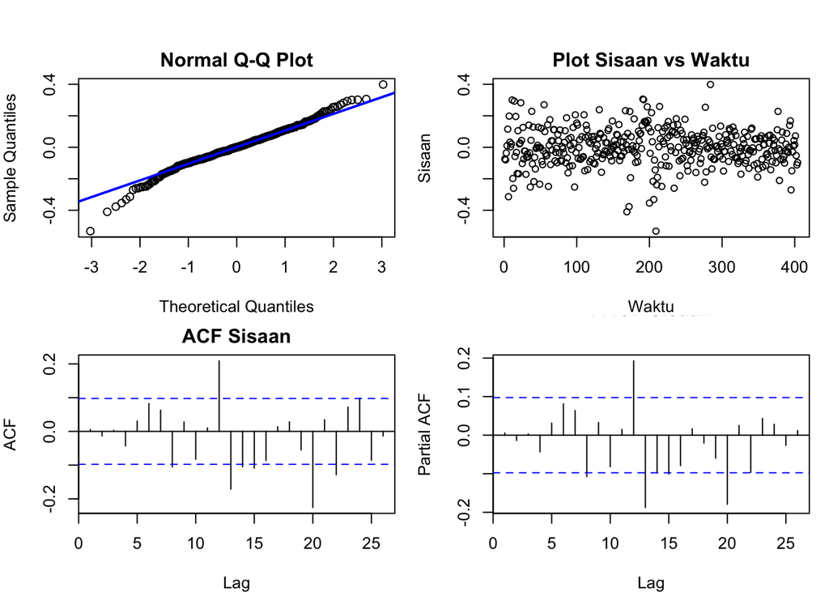

```r
sisaan.da <- model1.da$residuals

par(mfrow = c(2,2),
    mar = c(4,4,2,1),
    oma = c(0,0,2,0))

# Q-Q Plot
qqnorm(sisaan.da, main = "Normal Q-Q Plot")
qqline(sisaan.da, col = "blue", lwd = 2)

# Plot Sisaan vs Waktu
plot(sisaan.da, type = "p",
     main = "Plot Sisaan vs Waktu",
     xlab = "Waktu", ylab = "Sisaan")

# ACF
acf(sisaan.da, main = "ACF Sisaan")

# PACF
pacf(sisaan.da, main = "PACF Sisaan")
```

Berdasarkan plot kuantil-kuantil normal, sebagian besar sisaan pada bagian tengah cenderung mengikuti garis $45^{\circ}$, tetapi terdapat penyimpangan pada bagian ekor sehingga sisaan secara visual belum sepenuhnya mengikuti distribusi normal. Pada plot sisaan terhadap waktu, sisaan secara umum menyebar di sekitar nilai nol tanpa menunjukkan pola tren yang jelas, tetapi terdapat beberapa nilai ekstrem pada periode tertentu sehingga penyebaran sisaan belum sepenuhnya seragam. Sementara itu, plot ACF sisaan masih menunjukkan beberapa spike yang melewati batas signifikansi pada beberapa lag. Oleh karena itu, kondisi sisaan selanjutnya diperiksa menggunakan uji formal

#### Uji Formal

```r
#1) Sisaan Menyebar Normal
ks.test(sisaan.da, "pnorm", mean = mean(sisaan.da), sd = sd(sisaan.da))  #tolak H0 > sisaan tidak menyebar normal
```

```
##
##  Asymptotic one-sample Kolmogorov-Smirnov test
##
## data:  sisaan.da
## D = 0.050043, p-value = 0.2638
## alternative hypothesis: two-sided
```

Selain dengan eksplorasi, asumsi tersebut dapat diuji menggunakan uji formal. Pada tahapan ini uji formal yang digunakan untuk normalitas adalah uji Kolmogorov-Smirnov (KS). Hipotesis pada uji KS adalah sebagai berikut.

$H_0$ : Sisaan menyebar normal

$H_1$ : Sisaan tidak menyebar normal

Berdasarkan uji Kolmogorov-Smirnov, diperoleh p-value sebesar 0,2638 yang lebih besar dari taraf nyata 5% sehingga gagal tolak H0. Hal ini menunjukkan bahwa sisaan menyebar normal

```r
#2) Sisaan saling bebas/tidak ada autokorelasi
Box.test(sisaan.da, type = "Ljung")  #gagal tolak H0 > sisaan saling bebas
```

```
##
##  Box-Ljung test
##
## data:  sisaan.da
## X-squared = 0.013396, df = 1, p-value = 0.9079
```

Selanjutnya akan dilakukan uji formal untuk kebebasan sisaan menggunakan uji Ljung-Box. Hipotesis yang digunakan adalah sebagai berikut.

$H_0$ : Sisaan saling bebas

$H_1$ : Sisaan tidak saling bebas

Berdasarkan uji Ljung-Box, diperoleh *p-value* sebesar 0,9079 yang lebih besar dari taraf nyata 5% sehingga tak tolak $H_0$. Hal ini menunjukkan bahwa tidak terdapat autokorelasi pada sisaan atau sisaan sudah saling bebas

```r
#3) Sisaan homogen
Box.test((sisaan.da)^2, type = "Ljung")  #tolak H0 > sisaan tidak homogen
```

```
##
##  Box-Ljung test
##
## data:  (sisaan.da)^2
## X-squared = 7.156, df = 1, p-value = 0.007471
```

Hipotesis yang digunakan untuk uji kehomogenan ragam adalah sebagai berikut.

$H_0$ : Ragam sisaan homogen

$H_1$ : Ragam sisaan tidak homogen

Berdasarkan uji Ljung-Box pada kuadrat sisaan, diperoleh *p-value* sebesar 0,007471 yang lebih kecil dari taraf nyata 5% sehingga tolak $H_0$. Hal ini menunjukkan bahwa ragam sisaan tidak homogen

```r
#4) Nilai tengah sisaan sama dengan nol
t.test(sisaan.da, mu = 0, conf.level = 0.95)  #gagal tolak h0 > nilai tengah sisaan sama dengan 0
```

```
##
##  One Sample t-test
##
## data:  sisaan.da
## t = 0.029404, df = 403, p-value = 0.9766
## alternative hypothesis: true mean is not equal to 0
## 95 percent confidence interval:
##  -0.01144571  0.01179331
## sample estimates:
##    mean of x
## 0.0001737976
```

Terakhir, dengan uji-t, akan dicek apakah nilai tengah sisaan sama dengan nol. Hipotesis yang diujikan sebagai berikut.

$H_0$ : nilai tengah sisaan sama dengan 0

$H_1$ : nilai tengah sisaan tidak sama dengan 0

Berdasarkan uji t terhadap rataan sisaan, diperoleh *p-value* sebesar 0,9766 yang lebih besar dari taraf nyata 5% sehingga tak tolak $H_0$. Hal ini menunjukkan bahwa rataan sisaan tidak berbeda nyata dari nol

### Overfitting

Tahapan selanjutnya adalah *overfitting* dilakukan dengan menaikkan orde AR(p) dan MA(q) dari model ARIMA(3,0,0). Kandidat model *overfitting* adalah ARIMA(4,0,0) dan ARIMA(3,0,1).

```r
#---OVERFITTING---#
model1a.da=Arima(train.trans, order=c(4,0,0),method="ML")
summary(model1a.da)
```

```
## Series: train.trans
## ARIMA(4,0,0) with non-zero mean
##
## Coefficients:
##          ar1      ar2     ar3      ar4    mean
##       0.4426  -0.1180  0.1849  -0.0290  0.6711
## s.e.  0.0497   0.0536  0.0535   0.0497  0.0113
##
## sigma^2 = 0.01424:  log likelihood = 287.92
## AIC=-563.84   AICc=-563.62   BIC=-539.83
##
## Training set error measures:
##                        ME      RMSE        MAE MPE MAPE      MASE        ACF1
## Training set 0.0001731006 0.1186046 0.08923826 Inf  Inf 0.8287755 0.002733383
```

```r
lmtest::coeftest(model1a.da)
```

```
##
## z test of coefficients:
##
##            Estimate Std. Error z value  Pr(>|z|)
## ar1        0.442565   0.049703  8.9043 < 2.2e-16 ***
## ar2       -0.117980   0.053575 -2.2021 0.0276554 *
## ar3        0.184860   0.053494  3.4557 0.0005488 ***
## ar4       -0.028995   0.049674 -0.5837 0.5594192
## intercept  0.671076   0.011325 59.2552 < 2.2e-16 ***
## ---
## Signif. codes:  0 '***' 0.001 '**' 0.01 '*' 0.05 '.' 0.1 ' ' 1
```

```r
model1b.da=Arima(train.trans, order=c(3,0,1),method="ML")
summary(model1b.da)
```

```
## Series: train.trans
## ARIMA(3,0,1) with non-zero mean
##
## Coefficients:
##          ar1      ar2     ar3     ma1    mean
##       0.1817  -0.0039  0.1602  0.2641  0.6711
## s.e.  0.2752   0.1318  0.0547  0.2791  0.0112
##
## sigma^2 = 0.01423:  log likelihood = 288.08
## AIC=-564.16   AICc=-563.95   BIC=-540.15
##
## Training set error measures:
##                        ME      RMSE        MAE MPE MAPE      MASE          ACF1
## Training set 0.0001617066 0.1185567 0.08906159 Inf  Inf 0.8271347 -0.0001847882
```

```r
lmtest::coeftest(model1b.da)
```

```
##
## z test of coefficients:
##
##             Estimate Std. Error z value  Pr(>|z|)
## ar1        0.1816758  0.2751959  0.6602  0.509145
## ar2       -0.0038605  0.1317698 -0.0293  0.976628
## ar3        0.1602321  0.0546888  2.9299  0.003391 **
## ma1        0.2641291  0.2791267  0.9463  0.344011
## intercept  0.6711043  0.0112331 59.7436 < 2.2e-16 ***
## ---
## Signif. codes:  0 '***' 0.001 '**' 0.01 '*' 0.05 '.' 0.1 ' ' 1
```

```r
overfitting <- data.frame(
  Model = c("ARIMA(4,0,0)","ARIMA(3,0,0)", "ARIMA(3,0,1)"),
  AIC   = c(AIC(model1a.da),AIC(model1.da), AIC(model1b.da)),
  BIC   = c(BIC(model1a.da),BIC(model1.da), BIC(model1b.da))
)

overfitting
```

```
##          Model       AIC       BIC
## 1 ARIMA(4,0,0) -563.8364 -539.8279
## 2 ARIMA(3,0,0) -565.4958 -545.4887
## 3 ARIMA(3,0,1) -564.1588 -540.1503
```

Berdasarkan kedua model hasil *overfitting* di atas, model ARIMA(4,0,0) dan ARIMA(3,0,1) memiliki AIC yang lebih besar dibandingkan dengan model ARIMA(3,0,0). Selain itu, parameter pada model ARIMA(4,0,0) dan ARIMA(3,0,1) tidak seluruhnya signifikan pada taraf nyata 5%. Oleh karena itu, model ARIMA(3,0,0) akan tetap digunakan untuk melakukan peramalan

### Model Terbaik : ARIMA(3,0,0)

```r
model.terbaik=Arima(train.trans, order=c(3,0,0),method="ML")
summary(model.terbaik)
```

```
## Series: train.trans
## ARIMA(3,0,0) with non-zero mean
##
## Coefficients:
##          ar1      ar2     ar3    mean
##       0.4375  -0.1147  0.1723  0.6710
## s.e.  0.0490   0.0533  0.0490  0.0117
##
## sigma^2 = 0.01422:  log likelihood = 287.75
## AIC=-565.5   AICc=-565.35   BIC=-545.49
##
## Training set error measures:
##                        ME      RMSE        MAE MPE MAPE      MASE        ACF1
## Training set 0.0001737976 0.1186551 0.08937046 Inf  Inf 0.8300033 0.005737084
```

```r
lmtest::coeftest(model.terbaik)
```

```
##
## z test of coefficients:
##
##            Estimate Std. Error z value  Pr(>|z|)
## ar1        0.437505   0.048957  8.9365 < 2.2e-16 ***
## ar2       -0.114677   0.053289 -2.1520 0.0313985 *
## ar3        0.172253   0.048953  3.5188 0.0004335 ***
## intercept  0.671050   0.011652 57.5897 < 2.2e-16 ***
## ---
## Signif. codes:  0 '***' 0.001 '**' 0.01 '*' 0.05 '.' 0.1 ' ' 1
```

### Peramalan

Peramalan dilakukan menggunakan fungsi `forecast()`. Peramalan berikut ini dilakukan sepanjang data uji, yaitu 101 bulan ke depan

```r
# ---FORECAST---
ramalan.da <- forecast::forecast(model.terbaik, h = length(test.ts))
ramalan.da
```

```
##     Point Forecast     Lo 80     Hi 80     Lo 95     Hi 95
## 405      0.6209664 0.4681453 0.7737875 0.3872467 0.8546861
## 406      0.6427854 0.4759786 0.8095923 0.3876763 0.8978945
## 407      0.6404438 0.4732253 0.8076624 0.3847051 0.8961825
## 408      0.6522738 0.4833718 0.8211757 0.3939605 0.9105870
## 409      0.6614763 0.4913253 0.8316273 0.4012528 0.9216998
## 410      0.6637425 0.4933894 0.8340956 0.4032100 0.9242751
## 411      0.6657164 0.4952788 0.8361540 0.4050546 0.9263783
## 412      0.6679053 0.4973961 0.8384145 0.4071339 0.9286767
## 413      0.6690270 0.4984918 0.8395621 0.4082159 0.9298380
## 414      0.6696067 0.4990634 0.8401499 0.4087833 0.9304301
## 415      0.6701087 0.4995610 0.8406565 0.4092784 0.9309390
## 416      0.6704551 0.4999052 0.8410050 0.4096215 0.9312887
## 417      0.6706489 0.5000982 0.8411996 0.4098141 0.9314837
## 418      0.6707805 0.5002294 0.8413315 0.4099451 0.9316158
```

[output cut: 87 more lines]

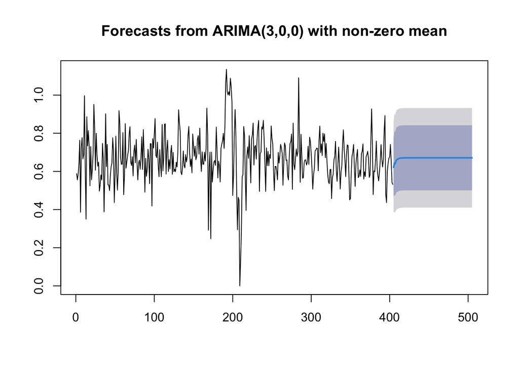

```r
data.ramalan.da <- ramalan.da$mean
plot(ramalan.da)
```

Berdasarkan hasil plot ramalan di atas yang masih dalam skala data transformasi, terlihat bahwa ramalan ARIMA(3,0,0) mengalami peningkatan pada beberapa periode awal, kemudian secara bertahap stabil dan cenderung konvergen menuju nilai sekitar 0,67 hingga akhir periode peramalan. Selanjutnya, hasil ramalan dikembalikan ke skala data asli melalui inverse transformasi Box-Cox dan pengurangan konstanta pergeseran agar dapat dibandingkan dengan data uji

```r
# Inverse transformasi Box-Cox
hasil <- (lambda_opt * data.ramalan.da + 1)^(1/lambda_opt)

# Kembalikan pergeseran konstanta
hasil <- hasil - c
hasil <- as.numeric(hasil)

# Bandingkan aktual vs forecast
perbandingan.da <- cbind(
  Aktual   = test.ts,
  Forecast = hasil
)

print(head(perbandingan.da, 10))
```

```
## Time Series:
## Start = 1
## End = 10
## Frequency = 1
##         Aktual  Forecast
##  1  0.20564284 0.2628714
##  2  0.96043343 0.3639012
##  3  0.51223677 0.3526895
##  4 -0.08898237 0.4102887
##  5  0.19431625 0.4567992
##  6 -0.45252525 0.4684908
##  7  0.23540872 0.4787528
##  8  0.65597668 0.4902188
##  9  0.69193016 0.4961298
## 10 -0.01598082 0.4991944
```

```r
# Hitung akurasi
akurasi_test <- accuracy(hasil, test.ts)
akurasi_test
```

```
##                  ME      RMSE      MAE       MPE     MAPE      ACF1 Theil's U
## Test set -0.2431803 0.3786651 0.327458 -3.034298 453.3852 0.1979977  1.305722
```

Berdasarkan hasil evaluasi peramalan pada data uji, diperoleh nilai ME sebesar -0,2432, RMSE sebesar 0,3787, dan MAE sebesar 0,3275. Nilai ME yang negatif menunjukkan bahwa secara rata-rata nilai ramalan cenderung lebih tinggi dibandingkan dengan nilai aktual. Hal ini menunjukkan adanya kecenderungan model untuk melakukan *overestimate* terhadap data aktual

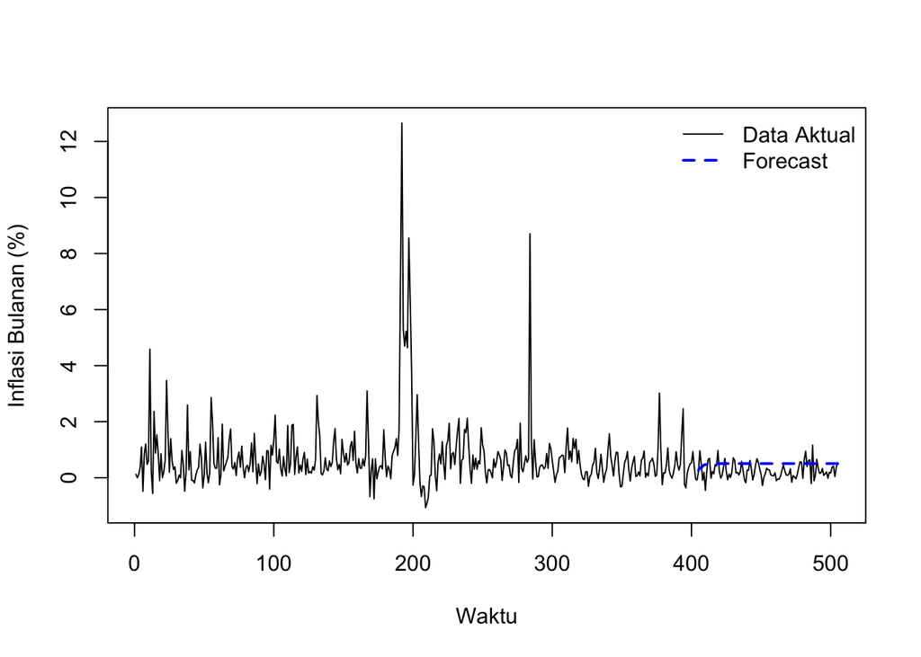

```r
# Plot data
ts.plot(datacpi.ts, col = "black", lty = 1,
        xlab = "Waktu", ylab = "Inflasi Bulanan (%)")

# Garis forecast
lines(405:(404+length(hasil)), hasil, col = "blue", lty = 2, lwd = 2)
legend("topright",
       legend = c("Data Aktual", "Forecast"),
       col = c("black", "blue"),
       lty = c(1,2), lwd = c(1,2), bty = "n")
```

Berdasarkan hasil peramalan pada data uji, terlihat bahwa nilai ramalan setelah transformasi balik cenderung berada di sekitar 0,5% per bulan dan relatif stabil sepanjang periode pengujian. Sementara itu, data aktual menunjukkan fluktuasi yang jauh lebih besar, dengan beberapa periode berada di bawah maupun di atas nilai ramalan. Perbedaan pola tersebut menunjukkan bahwa model cenderung menghasilkan ramalan yang lebih halus dan mendekati nilai rata-rata dibandingkan fluktuasi yang terjadi pada data aktual

Hal tersebut tercermin dari nilai ME sebesar -0,2432 yang menunjukkan bahwa secara rata-rata nilai ramalan cenderung lebih tinggi dibandingkan nilai aktual. Nilai RMSE sebesar 0,3787 dan MAE sebesar 0,3275 menunjukkan besarnya kesalahan peramalan pada data uji